# “Investigating Drought Climatic Aspects In A Puerto Rican Tropical Rainforest”

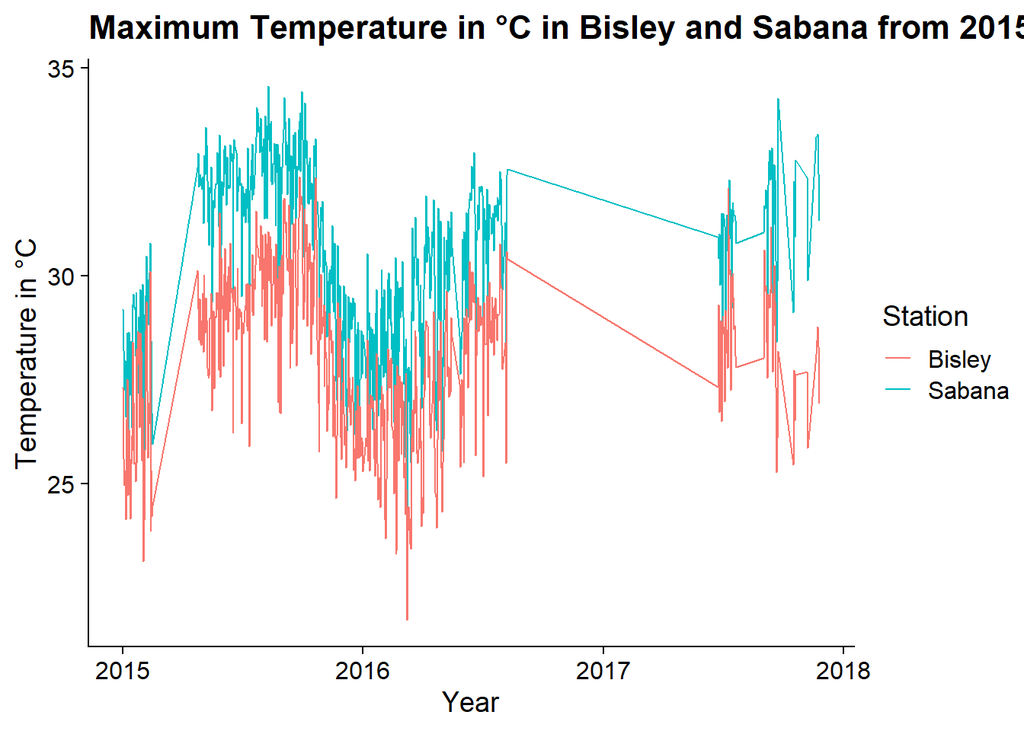

```r
inner_join(weatherTRACE %>% select(Timestamp, AirTC_Max), weatherBisley %>% select(Timestamp, AirTC_Max), by = "Timestamp") %>%
  ggplot(aes(x=Timestamp))+
  geom_line(aes(y = AirTC_Max.x, color = "Sabana")) +
  geom_line(aes(y = AirTC_Max.y, color = "Bisley")) +
  labs(title = "Maximum Temperature in \u00B0C in Bisley and Sabana from 2015 to 2017",
       y = "Temperature in \u00B0C",
       x = "Year",
       color = "Station")+
  theme_cowplot()
```

# Graph intepretation Through out 2015 to 2017, Bisley and TRACE had the similar pattern of changes in maximum temperature. However, TRACE had a higher temperature range through out these 3 years, ranging from 22.41 to 34.56 0B0C compared to Bisley’s temperature, which ranges from 20 to 32.28 0B0C. Again, this suggest the difference in topography contributes to different climatic attributes.

```r
model <- lm(weatherTRACE$`TOT_PREP(mm)`~ AirTC_Max + weatherTRACE$heatStatus + weatherTRACE$rainfallStatus, data = weatherTRACE)
summary(model)
```

```
##
## Call:
## lm(formula = weatherTRACE$`TOT_PREP(mm)` ~ AirTC_Max + weatherTRACE$heatStatus +
##     weatherTRACE$rainfallStatus, data = weatherTRACE)
##
## Residuals:
##     Min      1Q  Median      3Q     Max
## -26.130  -6.029  -2.203   2.105 180.990
##
## Coefficients:
##                                         Estimate Std. Error t value Pr(>|t|)
## (Intercept)                             114.6435    18.8577   6.079 1.68e-09
## AirTC_Max                                -3.3523     0.5838  -5.742 1.22e-08
## weatherTRACE$heatStatusDanger Hot        -5.3503     1.6257  -3.291 0.001031
## weatherTRACE$heatStatusExtreme Hot      -10.7782     2.7651  -3.898 0.000103
## weatherTRACE$heatStatusHot               -4.3277     4.1216  -1.050 0.293946
## weatherTRACE$rainfallStatusLow rainfall  -6.4058     1.0239  -6.256 5.72e-10
##
## (Intercept)                             ***
## AirTC_Max                               ***
## weatherTRACE$heatStatusDanger Hot       **
## weatherTRACE$heatStatusExtreme Hot      ***
## weatherTRACE$heatStatusHot
## weatherTRACE$rainfallStatusLow rainfall ***
## ---
## Signif. codes:  0 '***' 0.001 '**' 0.01 '*' 0.05 '.' 0.1 ' ' 1
##
## Residual standard error: 14.47 on 1062 degrees of freedom
## Multiple R-squared:  0.1499, Adjusted R-squared:  0.1459
## F-statistic: 37.46 on 5 and 1062 DF,  p-value: < 2.2e-16
```

```r
model1 <- lm(weatherBisley$`TOT_PREP(mm)`~ AirTC_Max + weatherBisley$heatStatus + weatherBisley$rainfallStatus , data = weatherBisley)
summary(model1)
```

```
##
## Call:
## lm(formula = weatherBisley$`TOT_PREP(mm)` ~ AirTC_Max + weatherBisley$heatStatus +
##     weatherBisley$rainfallStatus, data = weatherBisley)
##
## Residuals:
##    Min     1Q Median     3Q    Max
## -8.588 -3.430 -1.024  0.739 72.500
##
## Coefficients:
##                                          Estimate Std. Error t value Pr(>|t|)
## (Intercept)                               62.8532     9.4205   6.672 4.22e-11
## AirTC_Max                                 -1.0297     0.2166  -4.754 2.30e-06
## weatherBisley$heatStatusDanger Hot       -27.6877     6.3914  -4.332 1.63e-05
## weatherBisley$heatStatusExtreme Hot      -28.6342     6.4190  -4.461 9.11e-06
## weatherBisley$heatStatusHot              -30.4349     6.4889  -4.690 3.12e-06
## weatherBisley$heatStatusNormal           -30.1191     6.5307  -4.612 4.52e-06
## weatherBisley$rainfallStatusLow rainfall  -4.4675     0.4839  -9.233  < 2e-16
##
## (Intercept)                              ***
## AirTC_Max                                ***
## weatherBisley$heatStatusDanger Hot       ***
## weatherBisley$heatStatusExtreme Hot      ***
## weatherBisley$heatStatusHot              ***
## weatherBisley$heatStatusNormal           ***
## weatherBisley$rainfallStatusLow rainfall ***
## ---
## Signif. codes:  0 '***' 0.001 '**' 0.01 '*' 0.05 '.' 0.1 ' ' 1
##
## Residual standard error: 6.356 on 976 degrees of freedom
## Multiple R-squared:  0.1557, Adjusted R-squared:  0.1505
## F-statistic:    30 on 6 and 976 DF,  p-value: < 2.2e-16
```

```r
weatherTRACE <- weatherTRACE %>% mutate("Climate Stressors" = ifelse(heatStatus == "Extreme Danger Hot"  & rainfallStatus == "Low rainfall", 1, 0), Station = "TRACE")

weatherBisley <- weatherBisley %>% mutate("Climate Stressors" = ifelse(heatStatus == "Extreme Danger Hot" | heatStatus == "Danger Hot" & rainfallStatus == "Low rainfall", 1, 0), Station = "Bisley")
colnames(weatherBisley)[5] <- "Relative Humidity"


model2 <- glm(weatherTRACE$`Climate Stressors` ~ weatherTRACE$`TOT_PREP(mm)` + AirTC_Max + weatherTRACE$`TOT_PREP(mm)`*AirTC_Max, data = weatherTRACE, family = "binomial")
summary(model2)
```

```
##
## Call:
## glm(formula = weatherTRACE$`Climate Stressors` ~ weatherTRACE$`TOT_PREP(mm)` +
##     AirTC_Max + weatherTRACE$`TOT_PREP(mm)` * AirTC_Max, family = "binomial",
##     data = weatherTRACE)
##
## Deviance Residuals:
##      Min        1Q    Median        3Q       Max
## -2.74706  -0.00181   0.00000   0.00000   2.27991
##
## Coefficients:
##                                        Estimate Std. Error z value Pr(>|z|)
## (Intercept)                           -106.6961    13.7878  -7.738 1.01e-14 ***
## weatherTRACE$`TOT_PREP(mm)`             40.8060     7.2967   5.592 2.24e-08 ***
## AirTC_Max                                3.3693     0.4333   7.775 7.54e-15 ***
## weatherTRACE$`TOT_PREP(mm)`:AirTC_Max   -1.8161     0.3237  -5.610 2.02e-08 ***
## ---
## Signif. codes:  0 '***' 0.001 '**' 0.01 '*' 0.05 '.' 0.1 ' ' 1
##
## (Dispersion parameter for binomial family taken to be 1)
##
##     Null deviance: 844.72  on 1067  degrees of freedom
## Residual deviance: 137.75  on 1064  degrees of freedom
## AIC: 145.75
##
## Number of Fisher Scoring iterations: 14
```

```r
exp(coef(model2))
```

```
##                           (Intercept)           weatherTRACE$`TOT_PREP(mm)`
##                          4.596967e-47                          5.270207e+17
##                             AirTC_Max weatherTRACE$`TOT_PREP(mm)`:AirTC_Max
##                          2.905852e+01                          1.626558e-01
```

```r
model3 <- glm(weatherBisley$`Climate Stressors` ~ weatherBisley$`TOT_PREP(mm)` + AirTC_Max + weatherBisley$`TOT_PREP(mm)`*AirTC_Max, data = weatherBisley, family = "binomial")
summary(model3)
```

```
##
## Call:
## glm(formula = weatherBisley$`Climate Stressors` ~ weatherBisley$`TOT_PREP(mm)` +
##     AirTC_Max + weatherBisley$`TOT_PREP(mm)` * AirTC_Max, family = "binomial",
##     data = weatherBisley)
##
## Deviance Residuals:
##    Min      1Q  Median      3Q     Max
##  -8.49    0.00    0.00    0.00    8.49
##
## Coefficients:
##                                          Estimate Std. Error    z value
## (Intercept)                            -9.674e+15  3.681e+07 -262820146
## weatherBisley$`TOT_PREP(mm)`           -4.143e+14  4.222e+06  -98124217
## AirTC_Max                               3.149e+14  1.318e+06  238932193
## weatherBisley$`TOT_PREP(mm)`:AirTC_Max  1.062e+13  1.567e+05   67734445
##                                        Pr(>|z|)
## (Intercept)                              <2e-16 ***
## weatherBisley$`TOT_PREP(mm)`             <2e-16 ***
## AirTC_Max                                <2e-16 ***
## weatherBisley$`TOT_PREP(mm)`:AirTC_Max   <2e-16 ***
## ---
## Signif. codes:  0 '***' 0.001 '**' 0.01 '*' 0.05 '.' 0.1 ' ' 1
##
## (Dispersion parameter for binomial family taken to be 1)
##
##     Null deviance:  509.91  on 982  degrees of freedom
## Residual deviance: 4036.89  on 979  degrees of freedom
## AIC: 4044.9
##
## Number of Fisher Scoring iterations: 25
```

```r
exp(coef(model3))
```

```
##                            (Intercept)           weatherBisley$`TOT_PREP(mm)`
##                                      0                                      0
##                              AirTC_Max weatherBisley$`TOT_PREP(mm)`:AirTC_Max
##                                    Inf                                    Inf
```

```r
weatherAll <- rbind(weatherTRACE %>% select(- c(AirTC_Avg, total_Precip_month, total_Precip_year)), weatherBisley %>% select(-c(AirTC_Min, RH_Min)))

model4 <- lm(weatherAll$`TOT_PREP(mm)` ~ AirTC_Max + weatherAll$heatIndex + weatherAll$rainfallStatus + weatherAll$Station, data = weatherAll)
summary(model4)
```

```
##
## Call:
## lm(formula = weatherAll$`TOT_PREP(mm)` ~ AirTC_Max + weatherAll$heatIndex +
##     weatherAll$rainfallStatus + weatherAll$Station, data = weatherAll)
##
## Residuals:
##     Min      1Q  Median      3Q     Max
## -13.773  -4.967  -1.826   1.556 195.130
##
## Coefficients:
##                                       Estimate Std. Error t value Pr(>|t|)
## (Intercept)                           52.52278    6.61937   7.935 3.44e-15 ***
## AirTC_Max                             -2.12925    0.41560  -5.123 3.28e-07 ***
## weatherAll$heatIndex                   0.12984    0.05887   2.205   0.0275 *
## weatherAll$rainfallStatusLow rainfall -5.75403    0.59914  -9.604  < 2e-16 ***
## weatherAll$StationTRACE                5.39914    0.69410   7.779 1.15e-14 ***
## ---
## Signif. codes:  0 '***' 0.001 '**' 0.01 '*' 0.05 '.' 0.1 ' ' 1
##
## Residual standard error: 11.57 on 2046 degrees of freedom
## Multiple R-squared:  0.1224, Adjusted R-squared:  0.1207
## F-statistic: 71.37 on 4 and 2046 DF,  p-value: < 2.2e-16
```